# Prop 40, JR analysis: the reproduction AI generated, not reviewed yet

## Section 4: the wealth tax revenue

This section builds the revenue. At 5% of the base, it is $94.30B before anyone leaves and $100.91B at the valuation date. Removing the seven publicly reported moves leaves $72.05B. Leaving out three pre-filing departures and Zuckerberg, and halving for the chance the Act is struck down, gives the paper’s about $30B (p.23).

### 4.1 The baseline, before anyone leaves (eqs. 1 and 2)

Take each of the $N$ = 212 California billionaires on the 2025 Forbes list (with the authors’ corrections), subtract their directly held residential real estate (TRRE, total residential real estate; the Act exempts it), multiply what is left by the 5% rate, and add up. Their aggregate net worth is $1,894.8B. The authors’ workbook sums this row by row to **$94.30B**; the paper prints $94.20B (PDF p.19, eq. 2), a value typed into the workbook, 0.1% below its own sum. Every later number in the first version is built on the typed value, and each reproduces (note 6).

$$R_{\text{base}} = \sum_{i=1}^{N} \tau \times \text{TaxBase}_i, \qquad \text{TaxBase}_i = \text{NetWorth}_i - \text{TRRE}_i$$

The tax is assessed on net worth at 31 December 2026, so the authors grow every net worth by 7% to that valuation date and rebuild the base person by person in `final.csv`: 212 domestic rows, face value **$100.91B** (printed $100.9B, PDF p.19). That is exactly 1.0700 times the workbook’s $94.30B, so the person-level file and the workbook agree with each other, and both differ from the printed $94.20B. The 28 non-US-citizen residents ($146.3B of net worth) stay outside the base (PDF p.17).

### 4.2 The collectibility principle (eq. 3)

The authors count revenue only when it is “more likely than not” to be collected.

$$E[R] = q \times R_{\text{recognized}}$$

They borrow this test from the accounting rule for uncertain tax positions in company accounts (ASC 740-10, PDF p.20). It works at two levels. For each taxpayer: publicly reported moves, pre-filing departures and billionaires imputed from a Pareto curve are left out of the recognized base, $R_{\text{recognized}}$. For the Act as a whole: $q$ is the probability that the Act survives constitutional challenge, set at 0.50 (PDF pp.19-20). That value comes from the accounting standard’s 50% threshold, not from a legal assessment of the challenges, so it is **guesswork**.

### 4.3 The seven publicly reported moves (Table 7, eq. 4)

The chapter calls them “publicly confirmed pre-snapshot departures” (Table 7, PDF p.21). This OPA says “publicly reported moves”, because whether each ended legal residence in time is disputed ([disputes row 3](https://github.com/fhoces/opa-prop40/blob/main/comparison/DISPUTES.md)). Table 7 lists Page, Brin, Thiel, Hankey, Spielberg, Kalanick and Sacks as having moved out between the initiative’s filing and the 1 January 2026 residency date (PDF p.21). Removing their $28.85B leaves **$72.05B** in `final.csv`. The paper (eq. 4, p.22) and the authors’ README print $72.06B, the difference of two figures each rounded to two decimals (100.91 − 28.85), and the script and the chapter’s later pages use 72 (note 4): one value at three roundings. The paper then asks how big a behavioural response that is. It divides the share of revenue lost by the rate change, in percentage points (eq. 4, PDF p.22):

$$\varepsilon = \frac{\%\Delta \text{TaxBase}}{\Delta \text{TaxRate (p.p.)}}
= \frac{(100.9 - 72.06)/100.9}{5}$$

**R code for the implied semi-elasticity**

```r
eps7 <- 100 * (1 - nc$ceiling_recomputed / nc$domestic_total_grown) / (100 * inp("tax_rate"))
eps7
```

```
[1] 5.71903
```

This gives 5.72. The printed 5.73 is the same formula with the round ceiling, (100.9 − 72)/100.9/5 = 5.73, so the two differ only in rounding (note 4). A 1-point tax rate rise drives out about 5.7% of the base. The authors treat this as a floor, because it counts only departures that made the news (PDF pp.22-24).

### 4.4 The litigation discount and the collectible estimate (eqs. 5 to 8)

Removing three pre-filing departures as well ($0.88B) leaves $71.18B (printed $71.17B, PDF p.22). Mark Zuckerberg announced his move in February 2026, after the residency date. The authors exclude his $12.03B, because collecting it depends on the retroactive date surviving in court. That leaves a recognized base of **$59.15B** (eq. 5). Multiplying by $q$ = 0.50 gives

$$E[R] = q \times R_{\text{recognized}} = 0.50 \times 59.15 = 29.57$$

(printed $29.6B, eqs. 6 and 8, PDF p.23). Keeping Zuckerberg gives $35.59B (eq. 7). Moving the gray-zone names out gives $28.40B: these are the seven billionaires with departure signals short of confirmation, plus Jan Koum, Reed Hastings and Andy Fang, reported as considering a move (PDF p.23). Hence the printed range, $28.4B to $35.6B, around “approximately $30 billion”.

The Monte Carlo does not use this point estimate. It draws revenue from 0 to 72, whose mean is the paper’s central $36B (Step 1 and Section 5.4).

### 4.5 Validation against the literature (Table 8)

Brülhart et al. (2022) estimate that Swiss taxable wealth falls by about 43% per point of wealth tax, about 24% of it through people moving.

$$\eta_{\text{mig}} = 0.24 \times 43 = 10.32, \qquad \text{base lost} = 1 - (1 - 0.05)^{10.32}$$

**R code for the literature-implied base loss**

```r
lit_loss <- 1 - (1 - inp("tax_rate"))^inp("brulhart_semi_elasticity")
lit_loss
```

```
[1] 0.4110104
```

The authors keep only the moving part, 10.32, and apply it to the 5-point rate in log form: the base shrinks by **41.1%** (PDF p.24). Table 8 (PDF p.25) sets this beside the observed 28.6% from the seven publicly reported moves. This check does not enter the main estimate. Two things to notice. First, the Swiss estimate is for a recurring annual tax. The paper argues that taxpayers price the Act as the start of a recurring regime, so the recurring-tax estimate is the right benchmark (PDF p.25). Second, the BSZ analysis (Boll, Saez and Zucman) disputes exactly this transfer ([disputes row 1](https://github.com/fhoces/opa-prop40/blob/main/comparison/DISPUTES.md)).

## Section 5.1: the income tax the billionaires pay

This section estimates $C$, the income tax the billionaires pay each year. It is at most $5.8B if they are the 212 highest earners and about $3.3B if they are spread among the top 500 filers. The Monte Carlo draws between the two.

### The Pareto upper bound (eqs. 9 and 10)

The state publishes how many tax returns report income above $1M, $2M, $3M, $4M, $5M and $10M (Franchise Tax Board, FTB below: Personal Income Tax Annual Report 2024, Table B-4A). If top incomes follow a Pareto distribution, the log of those counts falls on a straight line against the log of the thresholds, with slope $-\alpha$. The fitted line gives $\hat\alpha$ = **1.438** (printed 1.44, $R^2$ = 0.9987, PDF p.26).

$$N(y) = A\,y^{-\alpha}, \qquad S(k, n) = \left(\frac{k}{n}\right)^{(\alpha - 1)/\alpha}$$

**R code for the Pareto fit figure**

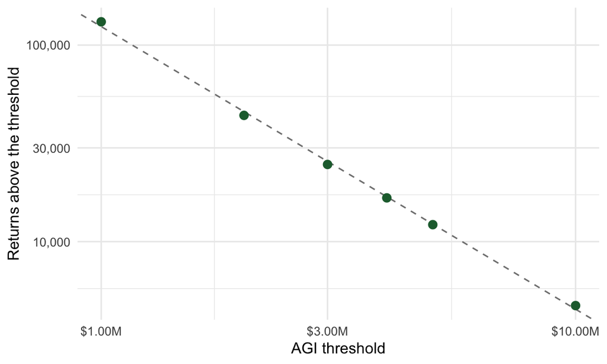

The six published filer counts against their AGI thresholds, log-log, with the fitted Pareto line (paper Figure 1, PDF p.27).

```r
d <- data.frame(y = pf$thresholds, n = pf$filer_counts)
ggplot(d, aes(y, n)) +
  geom_abline(intercept = log10(pf$A), slope = -pf$alpha, linetype = 2, colour = "grey50") +
  geom_point(size = 2.5, colour = "#1f6b3b") +
  scale_x_log10(labels = scales::label_dollar(scale = 1e-6, suffix = "M")) +
  scale_y_log10(labels = scales::label_comma()) +
  labs(x = "AGI threshold", y = "Returns above the threshold") +
  theme_minimal(base_size = 11)
```

$S(k, n)$ is the share of the bracket’s income that goes to its top $k$ of $n$ filers. With the top 212 of the 4,729 filers above $10M, the continuous formula gives 38.8% of the bracket’s $11.1B of tax. The script then builds a rank-by-rank income schedule and rescales it by 1.118 so that its top 212 match the continuous share (footnote 28, PDF p.28: the discrete sum undershoots by about 11%). Scaling Tax Year 2023 to FY 2024-25 collections ($130B in total) multiplies by 1.335. If the billionaires *are* the 212 highest earners, they pay **$5.76B a year**. That is the upper bound, and the top of $C$’s range.

### The dispersion Monte Carlo (Table 9)

Billionaires are ranked by wealth, not income, and many realise little income in a given year. So the script places the 212 billionaires at random among the top $K$ filers (without replacement, 100,000 draws for each $K$ from 212 to 2,000) and sums their tax. The wider the pool, the lower the expected total. The authors take $K \approx 500$ (“roughly the top decile of the bracket”, PDF p.28) as a reasonable floor, which gives the bottom of $C$’s range, $3.3B. The choice of $K$ = 500 is a judgement, not an estimate, so the range $C \in [3.3, 5.8]$ is labelled **guesswork** below.

**R code for Table 9**

```r
p8 <- printed[printed$table == "table8", ]
pv <- function(k, col) p8$printed[p8$row == k & p8$column == col]
tab8 <- t8 %>% transmute(
  `Pool size K` = format(K, big.mark = ","),
  `Mean` = num(mean_fy25, 3), `printed` = sapply(K, pv, "mean"),
  `P5` = num(p05_fy25, 3), `printed ` = sapply(K, pv, "p05"),
  `P95` = num(p95_fy25, 3), `printed  ` = sapply(K, pv, "p95"))
m8 <- sum(round(t8$mean_fy25, 2) == sapply(t8$K, pv, "mean")) +
      sum(round(t8$p05_fy25, 2) == sapply(t8$K, pv, "p05")) +
      sum(round(t8$p95_fy25, 2) == sapply(t8$K, pv, "p95"))
scroll(kable(tab8, align = "rrrrrrr", caption = "Table 9, $B per year (PDF p.30)"))
```

Table 9, $B per year (PDF p.30)

| Pool size K | Mean | printed | P5 | printed | P95 | printed |
| --- | --- | --- | --- | --- | --- | --- |
| 212 | 5.757 | 5.76 | 5.757 | 5.76 | 5.757 | 5.76 |
| 250 | 5.181 | 5.18 | 4.785 | 4.79 | 5.453 | 5.45 |
| 300 | 4.609 | 4.61 | 4.136 | 4.14 | 5.007 | 5.01 |
| 400 | 3.828 | 3.83 | 3.331 | 3.33 | 4.314 | 4.31 |
| 500 | 3.308 | 3.31 | 2.829 | 2.83 | 3.818 | 3.82 |
| 750 | 2.536 | 2.54 | 2.116 | 2.12 | 3.033 | 3.03 |
| 1,000 | 2.099 | 2.10 | 1.726 | 1.73 | 2.572 | 2.57 |

21 of the 21 cells round to the printed value; the tests hold this at the printed rounding (`tests/testthat/test-income-tax-mc.R`).

## Section 5.2: from an annual loss to a present value (eqs. 11 to 14)

This is the step that makes the result. The wealth tax is collected **once**. The income tax of anyone who leaves is lost **every year, for ever**, and a perpetuity paying $C$ a year is worth $C/r$ today.

$$PV = \frac{C}{r}, \qquad NPV = WT - f \cdot \frac{C}{r}$$

$$\text{or, with growth:}\qquad PV = \frac{C}{r - g}, \qquad NPV = WT - f \cdot \frac{C}{r - g}$$

At a rate of 1.5% a perpetuity is worth 1/0.015, about 67 years of payments; at 4.5%, about 22. The paper’s text then argues the lost stream grows with the billionaires’ wealth, making it a growing perpetuity, $C/(r-g)$ (PDF p.31). It calibrates $r - g$ at about 1.5% from the S&P 500’s dividend yield, and presents scenarios at 1.5%, 3.0% and 4.5% (PDF p.32).

Three things are worth knowing before reading the rest:

- **Which rate is drawn.** The chapter’s eq. 18 and its code (`NPV_dist_v8.R`) draw the 1.5% to 4.5% rate as $r - g$, the discount rate net of growth, and the NBER README describes the draw the same way. One sentence after eq. 19 writes $C/r$ (PDF p.35) (note 3). The first version’s code divides by plain $r$ (note 2). The explorer’s dial for further growth on top of the drawn $r - g$ is this OPA’s illustration, not part of the authors’ model.
- **The loss is not scaled by $q$.** People who left do not come back if the Act is struck down, so the income tax loss stays even when the wealth tax collects nothing (PDF p.33).
- **The horizon.** The authors assume leavers do not come back, because the Act permanently lifts the constitutional cap on taxes on intangible property and lets the Legislature change the Act by a two-thirds vote (chapter PDF p.32). Treating the loss as permanent is one of the disputed choices: the BSZ analysis argues the loss should be temporary and gives five years, the payment period, as an example (BSZ PDF p.27) ([disputes row 2](https://github.com/fhoces/opa-prop40/blob/main/comparison/DISPUTES.md)).

## Section 5.3: the break-even departure share (Table 10, eq. 15)

Set NPV to zero and solve for the departure share. The tax pays for itself only if less than $x^*$ of the income tax base leaves.

$$x^* = \frac{WT \cdot (r - g)}{C}$$

The paper evaluates it at its central revenue, $36B ($q \times 72$), and the midpoint income tax, $4.55B (PDF p.33).

**R code for Table 10**

```r
wt36 <- 0.5 * nb$wt_max
n10 <- compute_npv_table10(scenarios = list(central = list(label = "Central", WT = wt36, C = 4.55)))
pn <- printed[printed$table == "nber_table10", ]
mn10 <- sum(abs(round(100 * n10$break_even_pct, 1) - pn$printed[match(paste0("central@", n10$r), pn$row)]) < 1e-9)
scroll(kable(n10 %>% transmute(`WT ($B)` = num(WT, 0), `C ($B)` = num(C, 2), `r - g` = pct(100 * r),
                               `x*` = pct(100 * break_even_pct),
                               printed = pct(pn$printed[match(paste0("central@", r), pn$row)])),
             align = "rrrrr", caption = "Table 10 (PDF p.34)"))
```

Table 10 (PDF p.34)

| WT ($B) | C ($B) | r - g | x* | printed |
| --- | --- | --- | --- | --- |
| 36 | 4.55 | 1.5% | 11.9% | 11.9% |
| 36 | 4.55 | 3.0% | 23.7% | 23.7% |
| 36 | 4.55 | 4.5% | 35.6% | 35.6% |

3 of the 3 cells match the printed digit. The central departure share, $E[f]$ = 0.45, is above every one of them, which is why the mean NPV comes out negative (PDF p.34). A check that is not an input: plugging each $x^*$ back into the NPV formula must give exactly zero (see internal identities).

## Section 5.4: the Monte Carlo behind the headline (eqs. 16 to 19)

Draw the four inputs independently and uniformly, 100,000 times, and average the NPV (PDF p.35).

$$WT \sim U[\$0\text{B}, \$72\text{B}], \quad C \sim U[\$3.3\text{B}, \$5.8\text{B}], \quad
(r - g) \sim U[0.015, 0.045], \quad f \sim U[0.30, 0.60]$$

Two details matter:

1. **Revenue is drawn from zero.** The mean of $U[0, 72]$, $36B, is $0.5 \times 72$, the paper’s central estimate (PDF p.33). This is the only place $q$ appears in the code: there is no explicit multiplier (note 5). The script’s comment says the draw “embeds litigation range”, and the chapter also grounds the 0 in unreported departures (fn.32, PDF p.34). A uniform draw from 0 is a different assumption from a survive-or-not coin flip on a fixed base. The two share a mean, not a distribution.
2. **The departure share is drawn on its own**, not tied to revenue. Revenue lost and income tax lost do not move together in a draw.

**R code for Section 5.4**

```r
s <- tr("npv_mc_nber_summary")
scroll(kable(data.frame(
  ` ` = c("reproduced (seed 2026)", "printed (PDF p.35)"),
  `Mean` = c(num(s$mean, 2), num(h("nber", "mc_mean_npv", "printed"))),
  `Median` = c(num(s$median, 2), num(h("nber", "mc_median_npv", "printed"))),
  `SD` = c(num(s$sd, 2), num(h("nber", "mc_sd_npv", "printed"))),
  `% negative` = c(num(s$pct_negative, 2), num(h("nber", "mc_pct_negative", "printed"))),
  check.names = FALSE), align = "lrrrr",
  caption = "NPV Monte Carlo, $B, seed 2026, 100,000 draws"))
```

NPV Monte Carlo, $B, seed 2026, 100,000 draws

|  | Mean | Median | SD | % negative |
| --- | --- | --- | --- | --- |
| reproduced (seed 2026) | −38.89 | −35.26 | 37.62 | 85.17 |
| printed (PDF p.35) | −38.9 | −35.3 | 37.6 | 85.2 |

This OPA’s R port replays the authors’ script exactly (same seed, same draw order) and agrees with an unmodified run of `NPV_dist_v8.R` to machine precision (`tests/testthat/test-npv-mc.R`). The printed summary reproduces to within Monte Carlo error, with no systematic gap. Its exact expectation is −$38.98B, which rounds to −39.0 rather than the printed −38.9: the printed value is the seeded run’s, not the expectation. The explorer shows the exact expectations and says so.

**R code for the NPV distribution figure**

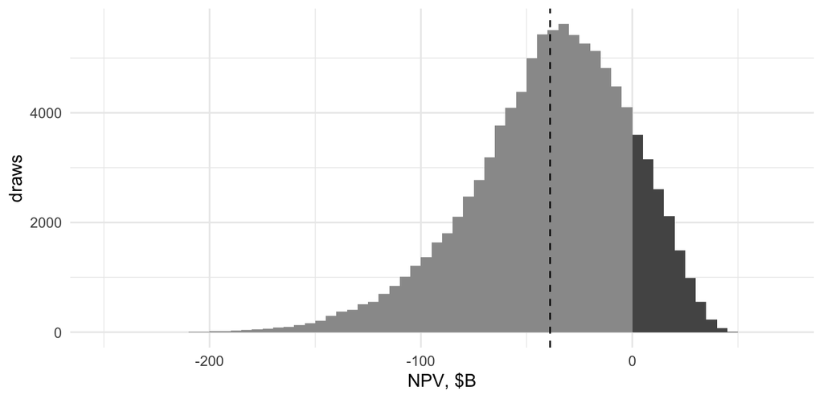

The distribution of simulated NPV (paper Figure 3, PDF p.35). Draws below zero in the lighter gray; the dashed line is the mean.

```r
ggplot(data.frame(npv = mcn$draws$npv), aes(npv, fill = npv < 0)) +
  geom_histogram(binwidth = 5, boundary = 0) +
  geom_vline(xintercept = mean(mcn$draws$npv), linetype = 2) +
  scale_fill_manual(values = c(`TRUE` = "#9a9a9a", `FALSE` = "#555555"), guide = "none") +
  coord_cartesian(xlim = c(-250, 70)) +
  labs(x = "NPV, $B", y = "draws") + theme_minimal(base_size = 11)
```

## Every input, by origin

This section is not in the paper: it re-sorts every input by *how much evidence stands behind it*, the question a reader who wants to argue with the result has to answer first.

**The headline:** 4 of the authors’ 5 inputs that move the result in the explorer are guesswork. The explorer’s other two dials (an extra litigation weight and further growth) are this OPA’s settings. The one labelled data, the revenue ceiling, rests on a legal judgement about who counts as having left (disputes row 3). The data and research inputs (the Forbes base, the FTB brackets, the Pareto fit) fix the *scale*. Whether the NPV is negative is decided by the guesswork: how wide the revenue draw is, where the income tax range stops, which rate is used, and whether the lost income tax is permanent.[^3]

- **data**: read off a public dataset or the authors’ own person-level file, and recomputable from it.
- **research**: an estimate taken from a published paper.
- **guesswork**: set by assumption. Some are bounded by evidence, but no dataset or estimate pins the value itself.
- **scenario**: a choice about which policy or counterfactual is being estimated.
- **derived**: a value another row implies.

**R code for the input table**

```r
dials <- site_dials(rc)
dial_rows <- do.call(rbind, lapply(dials, function(d) data.frame(
  input = if (d$key == "g") d$sym else d$key, origin = d$origin, what = d$label, `value(s)` = paste(d$labels, collapse = "; "),
  where = "explorer dial (R/site.R)", check.names = FALSE)))
# The rows only the first version uses (version "ssrn") go to the appendix.
first_only <- inputs$version == "ssrn"
inp_row <- function(x) data.frame(input = x$input_id, origin = x$label, what = x$description,
  `value(s)` = ifelse(is.na(x$value), "1.5% to 4.5%", vapply(x$value, function(v) format(signif(v, 6)), "")),
  where = x$source, check.names = FALSE)
odf <- rbind(inp_row(inputs[!first_only, ]), dial_rows)
scroll(kable(odf, caption = "Inputs by origin (export/r/inputs.csv, then the explorer's dials)"))
```

Inputs by origin (export/r/inputs.csv, then the explorer's dials)

| input | origin | what | value(s) | where |
| --- | --- | --- | --- | --- |
| n_billionaires | data | CA billionaires in the domestic base | 212 | CA_Billionaires_Revenues_and_Migration_final.xlsx!Summary_Preferred!D15 |
| baseline_net_worth | data | Aggregate net worth, 212 domestic billionaires | 1894.8 | CA_Billionaires_Revenues_and_Migration_final.xlsx!Summary_Preferred!E15 |
| tax_rate | data | Statutory wealth tax rate | 0.05 | CA_Billionaires_Revenues_and_Migration_final.xlsx!Calculations_Preferred!N3 |
| pareto_alpha | research | Pareto tail parameter fit to FTB AGI thresholds | 1.43789 | monte_carlo_sim.R:33-44 (FTB PIT Annual Report 2024, Table B-4A) |
| bracket_tax_ty23 | data | TY2023 tax liability, $10M+ AGI bracket | 11.1 | monte_carlo_sim.R:51 (FTB Table B-4A) |
| total_pit_fy25 | data | Total FY2024-25 PIT collections | 130 | monte_carlo_sim.R:89 (CA State Controller cash receipts) |
| rauh_mc_c_min | guesswork | Annual CA income tax of billionaires: lower bound of the draw | 3.3 | NPV_dist.R; paper eq.23 (from the K=500 dispersion draw); NPV_dist_v8.R:21 (NBER chapter p.1, pp.29-31) |
| rauh_mc_c_max | guesswork | Annual CA income tax of billionaires: upper bound of the draw | 5.8 | NPV_dist.R; paper eq.23 (Pareto upper bound); NPV_dist_v8.R:21 (NBER chapter p.1, pp.29-31) |
| rauh_mc_r_min | research | Discount rate draw: lower bound | 0.015 | NPV_dist.R:47; paper eq.24 (S&P 500 dividend yield anchor p.18; eq.19-20 instead specify r-g); NPV_dist_v8.R:22 (NBER chapter p.32, r-g) |
| rauh_mc_r_max | research | Discount rate draw: upper bound | 0.045 | NPV_dist.R:47; paper eq.24; NPV_dist_v8.R:22 (NBER chapter p.32) |
| nber_mc_f_min | guesswork | NBER departure fraction of the income tax base: lower bound (drawn independently of WT) | 0.3 | NPV_dist_v8.R; Jaros and Rauh NBER c15504 Sec 5.4 |
| nber_mc_f_max | guesswork | NBER departure fraction of the income tax base: upper bound | 0.6 | NPV_dist_v8.R; Jaros and Rauh NBER c15504 Sec 5.4 |
| q_litigation_survival | guesswork | Probability the Act survives constitutional challenge (ASC 740-10 more-likely-than-not) | 0.5 | NBER_2026_litigation_weighted/README.md (assumptions table); not an explicit multiplier in NPV_dist_v8.R - see NOTES.md note 5 |
| nber_growth_rate | guesswork on data | Growth applied to the Jan-1-2026 snapshot to the Dec-31-2026 valuation date | 0.07 | final.csv (net_worth_usd_7pct column); NBER README assumptions table |
| nber_ceiling_hardcoded | data | wt_max literal in NPV_dist_v8.R (script uses this, not the value re-derived from final.csv) | 72 | NPV_dist_v8.R:19 |
| nber_ceiling_recomputed | derived | wt_max re-derived from final.csv: domestic total minus 7 removed_departed rows | 72.0515 | R/nber_final.R:compute_nber_ceiling() from final.csv |
| nber_international_net_worth | data | 28 international billionaires excluded from the domestic base | 146.3 | final.csv (panel == international, net_worth_usd) |
| nber_departed_four_grown | data | Grown taxable wealth of 4 of the 7 publicly reported moves (Page, Thiel, Hankey, Kalanick) | 314.823 | final.csv (removed_departed rows, wealth_in_tax_base_usd_7pct) |
| nber_spielberg_sacks_net_worth | data | Net worth of 2 of the 7 publicly reported moves (Spielberg, Sacks) | 9 | final.csv (removed_departed rows, net_worth_usd) |
| wt_lo | guesswork | Lowest revenue the draw can pick ($B) | 0; 35; 45.59 | explorer dial (R/site.R) |
| wt_hi | data | Highest revenue the draw can pick ($B) | 55.10; 67.51; 72 | explorer dial (R/site.R) |
| q | guesswork | Extra litigation weight on the revenue | 1 (none extra); 0.75; 0.50 | explorer dial (R/site.R) |
| c | guesswork | Billionaires' yearly California income tax ($B) | 3.3 to 5.8; 3.3 only; 5.8 only | explorer dial (R/site.R) |
| rate | guesswork | Discount rate net of growth | 1.5% to 4.5%; 1.5% only; 4.5% only | explorer dial (R/site.R) |
| f | guesswork | Share of the income tax base that leaves | tied to revenue; 0.30 to 0.60; 0.283 fixed | explorer dial (R/site.R) |
| Δg | guesswork | Further growth of the lost income tax | 0; 0.5%; 1.0% | explorer dial (R/site.R) |

**R code for the input counts**

```r
# The levels list every origin present, so no row falls out of the count.
origin_levels <- union(c("data", "research", "guesswork", "guesswork on data", "scenario", "derived"),
                       unique(odf$origin))
cnt <- as.data.frame(table(factor(odf$origin, levels = origin_levels)))
stopifnot(sum(cnt$Freq) == nrow(odf))
names(cnt) <- c("origin", "rows")
scroll(kable(cnt, caption = paste0("Rows of the table above (", nrow(odf), "), by origin. ",
                                   "The last ", length(dials), " rows are the explorer's dials.")))
```

Rows of the table above (26), by origin. The last 7 rows are the explorer's dials.

| origin | rows |
| --- | --- |
| data | 10 |
| research | 3 |
| guesswork | 11 |
| guesswork on data | 1 |
| scenario | 0 |
| derived | 1 |

## What reproduces

**R code for the output checks**

```r
# The chapter's PDF page for each figure it prints (typed, like the printed values), and a
# plain label for each output id (outputs.csv has no description column).
page_nber <- c(revenue_baseline = "19", nber_domestic_grown = "19", nber_ceiling = "21",
               nber_international = "17", pareto_alpha = "26", income_tax_mc_k212 = "30",
               income_tax_mc_k300 = "30", income_tax_mc_k500 = "30", npv_mc_nber_mean = "35",
               npv_mc_nber_median = "35", npv_mc_nber_pct_negative = "35")
what_nber <- c(revenue_baseline = "Baseline revenue, before anyone leaves ($B)",
               nber_domestic_grown = "Baseline grown 7% to the valuation date ($B)",
               nber_ceiling = "Revenue left after the seven publicly reported moves ($B)",
               nber_international = "Net worth of the non-US-citizen residents left out ($B)",
               pareto_alpha = "Pareto tail parameter, alpha",
               income_tax_mc_k212 = "Yearly income tax C, billionaires among the top 212 filers ($B)",
               income_tax_mc_k300 = "Yearly income tax C, billionaires among the top 300 filers ($B)",
               income_tax_mc_k500 = "Yearly income tax C, billionaires among the top 500 filers ($B)",
               npv_mc_nber_mean = "Mean NPV, seeded run ($B)",
               npv_mc_nber_median = "Median NPV, seeded run ($B)",
               npv_mc_nber_pct_negative = "Share of draws below zero (%)")
ob <- outputs[outputs$output_id %in% names(page_nber), ]
top_id <- ob$output_id[which.max(ob$abs_diff)]
stopifnot(top_id == "revenue_baseline")   # the prose below names it as note 6
o <- ob %>% transmute(output = what_nber[output_id], reproduced = signif(value, 6),
  printed = printed_value, `abs diff` = signif(abs_diff, 2), page = page_nber[output_id])
# The rows whose reproduced value does not round to the digits the paper prints.
digits_printed <- vapply(as.character(ob$printed_value), function(p) nchar(sub("^[^.]*[.]?", "", p)), 0)
off_print <- ob$output_id[abs(round(ob$value, digits_printed) - ob$printed_value) > 1e-9]
stopifnot(setequal(off_print, c("revenue_baseline", "nber_ceiling")))   # the prose names these two
# One cat() call: the prose, then the table, so the code shows in one fold.
top_rel <- 100 * max(ob$abs_diff) / ob$printed_value[ob$output_id == top_id]
cat("The code reproduces the chapter's published results (tests in `tests/testthat/`). ",
    "The simulated figures lie within four Monte Carlo standard errors of the print. ",
    "The deterministic figures round to the printed digit, apart from ",
    c("one", "two", "three", "four")[length(off_print)], " where the paper prints a typed or ",
    "rounded intermediate value: the baseline revenue, a typed 94.20 ",
    "([note 6](materials.html#reproduction-notes)), and the ceiling, the difference of two rounded ",
    "figures ([note 4](materials.html#reproduction-notes)). The larger gap is the baseline revenue's, ",
    num(max(ob$abs_diff), 2), " (", num(top_rel, 1), "%). Table 9's 21 cells and Table 10's 3 cells, ",
    "shown above, match as well.^[The first version's own outputs are in the ",
    "[appendix](#appendix-first-version).]\n",
    paste(capture.output(scroll(kable(o, row.names = FALSE))), collapse = "\n"), sep = "")
```

The code reproduces the chapter’s published results (tests in `tests/testthat/`). The simulated figures lie within four Monte Carlo standard errors of the print. The deterministic figures round to the printed digit, apart from two where the paper prints a typed or rounded intermediate value: the baseline revenue, a typed 94.20 (note 6), and the ceiling, the difference of two rounded figures (note 4). The larger gap is the baseline revenue’s, 0.10 (0.1%). Table 9’s 21 cells and Table 10’s 3 cells, shown above, match as well.[^4]

| output | reproduced | printed | abs diff | page |
| --- | --- | --- | --- | --- |
| Pareto tail parameter, alpha | 1.43789 | 1.44 | 0.00210 | 26 |
| Yearly income tax C, billionaires among the top 212 filers ($B) | 5.75702 | 5.76 | 0.00300 | 30 |
| Yearly income tax C, billionaires among the top 300 filers ($B) | 4.60902 | 4.61 | 0.00098 | 30 |
| Yearly income tax C, billionaires among the top 500 filers ($B) | 3.30815 | 3.31 | 0.00180 | 30 |
| Baseline revenue, before anyone leaves ($B) | 94.30430 | 94.20 | 0.10000 | 19 |
| Baseline grown 7% to the valuation date ($B) | 100.90600 | 100.90 | 0.00560 | 19 |
| Revenue left after the seven publicly reported moves ($B) | 72.05150 | 72.06 | 0.00850 | 21 |
| Net worth of the non-US-citizen residents left out ($B) | 146.30000 | 146.30 | 0.00000 | 17 |
| Mean NPV, seeded run ($B) | -38.88630 | -38.90 | 0.01400 | 35 |
| Median NPV, seeded run ($B) | -35.25550 | -35.30 | 0.04500 | 35 |
| Share of draws below zero (%) | 85.17200 | 85.20 | 0.02800 | 35 |

**R code for the list of reproduction notes**

```r
mm <- readLines("../NOTES.md")
mm_lines <- sub("^## ", "", grep("^## [0-9]+\\.", mm, value = TRUE))
mm_first <- grepl("^[0-9]+\\. First version: ", mm_lines)
# each note's kind, from the "**Kind:**" line under its heading
mm_kind <- sub("^[*][*]Kind:[*][*] ([^.]+)[.].*", "\\1", grep("^[*][*]Kind:[*][*] ", mm, value = TRUE))
stopifnot(length(mm_kind) == length(mm_lines),
          all(mm_kind %in% c("rounded or typed input", "seed variation", "documentation")))
word <- function(n) c("One", "Two", "Three", "Four", "Five", "Six", "Seven", "Eight", "Nine", "Ten")[n]
kinds <- c(`rounded or typed input` = "rounded or typed input", `seed variation` = "seed variation",
           documentation = "documentation note")
by_kind <- vapply(names(kinds), function(k) {
  n <- sum(mm_kind == k)
  paste0(tolower(word(n)), " ", kinds[[k]], if (n > 1) "s" else "")
}, "")
cat(paste0(
  word(length(mm_lines)), " notes record where the authors' text, their READMEs and their code ",
  "describe the same step differently. None is a failure to reproduce a printed result. By kind: ",
  paste(by_kind[-length(by_kind)], collapse = ", "), " and ", by_kind[length(by_kind)], ". ",
  word(sum(!mm_first)), " of them concern the chapter. This OPA records them rather than changing the code.",
  "^[The other ", tolower(word(sum(mm_first))), " concern only the authors' first version: ",
  paste(paste0(sub("First version: ", "", mm_lines[mm_first]), " (", mm_kind[mm_first], ")"), collapse = "; "), ".]\n\n",
  paste0(mm_lines[!mm_first], " (", mm_kind[!mm_first], ")", collapse = "\n"),
  "\n\nFull text: [the materials page](materials.html#reproduction-notes).\n"))
```

Ten notes record where the authors’ text, their READMEs and their code describe the same step differently. None is a failure to reproduce a printed result. By kind: three rounded or typed inputs, one seed variation and six documentation notes. Five of them concern the chapter. This OPA records them rather than changing the code.[^5]

3. The sentence after eq. 19 writes C/r where the draw is (r - g) (documentation)
4. NBER ceiling: one quantity at three roundings (72 in the script, 72.06 in the README and eq. 4, 72.05 in `final.csv`) (rounded or typed input)
5. The litigation weight `q = 0.50` is carried by the revenue draw, not by a multiplier in the code (documentation)
6. Baseline revenue: the paper types 94.20 and builds on it; the workbook’s own sum is 94.30 (rounded or typed input)
7. The top 212’s share of bracket tax is printed as 39.0% and as 38.8% for one formula (documentation)

Full text: the materials page.

### Internal identities

These checks compare the pipeline with itself, not with the paper. Each value should be zero or small.

**R code for the consistency checks**

```r
n_cell <- site_grid_cell(grid, as.list(site_named()$nber))
se_n <- mcn$summary$sd / sqrt(mcn$summary$n)
checks <- data.frame(
  identity = c(
    "Table 10's x* plugged into NPV = WT - x* C/(r - g) gives 0 (max |NPV|, $B)",
    "The explorer's value at the main setting equals the pipeline's analytic mean (abs diff, $B)",
    "Seeded MC mean vs exact expectation, in MC standard errors",
    "Share negative: exact integration (quadrature) vs seeded MC (points)",
    "Ceiling: domestic total minus the 7 departures, recomputed, minus the script's 72 ($B)"),
  value = c(max(abs(with(n10, WT - break_even_pct * C / r))),
    abs(n_cell$mean_npv - tr("npv_mc_nber_analytic_mean")),
    (mcn$summary$mean - tr("npv_mc_nber_analytic_mean")) / se_n,
    n_cell$pct_negative - mcn$summary$pct_negative,
    nc$ceiling_recomputed - nb$wt_max))
checks$value <- vapply(checks$value, function(v) format(signif(v, 3)), "")
scroll(kable(checks))
```

| identity | value |
| --- | --- |
| Table 10's x* plugged into NPV = WT - x* C/(r - g) gives 0 (max \|NPV\|, $B) | 7.11e-15 |
| The explorer's value at the main setting equals the pipeline's analytic mean (abs diff, $B) | 0 |
| Seeded MC mean vs exact expectation, in MC standard errors | 0.79 |
| Share negative: exact integration (quadrature) vs seeded MC (points) | 0.149 |
| Ceiling: domestic total minus the 7 departures, recomputed, minus the script's 72 ($B) | 0.0515 |

The seeded mean sits within about one Monte Carlo standard error of the exact expectation. The printed −38.9 equals the rounded seeded run, not the rounded expectation, −39.0. Which one a printed digit matches is a rounding coincidence.[^6]

## Reproducing this document

```bash
cd rjkdc-analysis
export RAUH_REPO_DIR=/path/to/wealth_tax     # clone of github.com/bjaros20/wealth_tax at 25e84dd
Rscript -e 'targets::tar_make()'             # writes the targets store, export/r/, site/data/, site/explorer/grid.js
Rscript tests/testthat.R                     # full suite
quarto render site/repro.qmd
```

The authors’ repository is MIT licensed but not redistributed here; the tests that re-run the authors’ own scripts skip cleanly without it, and the rest of the suite does not need it.

## Appendix: the authors’ first version (March 2026)

This appendix is not part of the account above. It records what the pipeline also reproduces: the authors’ first version, Rauh, Jaros, Kearney, Doran and Cosso, *The Net Present Value of the Billionaire Tax Act*, Hoover Institution, SSRN 6340778 (17 March 2026). Page numbers in this appendix are that version’s PDF pages. Its Pareto fit and income tax Monte Carlo are the ones in Section 5.1 above (its Table 8 is the chapter’s Table 9). Its revenue part and its Monte Carlo differ.

**Revenue.** It starts from the same $94.20B baseline, without growth to a valuation date or a litigation discount. Six publicly reported moves leave $67.51B (printed $67.51B, p.11); ten reported departures leave $55.10B (printed $55.1B, p.13). The Swiss semi-elasticity, applied linearly (10.32 × 5 = 51.6% of the base), gives $45.59B (printed $45.59B, p.14). The preferred “approximately $40 billion (range: $35-46 billion)” (p.14) is not computed anywhere in the authors’ code. Every step after the baseline uses a typed 94.2 rather than the workbook’s 94.30, and each printed result built on it reproduces (note 6).

**NPV by scenario and break-even (its Tables 9 and 10).** The departure share is tied to revenue, $f = 1 - WT/94.2$, so revenue lost and income tax lost move together.

**R code for the first version’s Table 9**

```r
p9 <- printed[printed$table == "table9", ]
t9p <- t9 %>% mutate(key = paste0(scenario, "@", r)) %>% rowwise() %>% mutate(
  pv_printed = p9$printed[p9$row == key & p9$column == "pv_lost"],
  npv_printed = p9$printed[p9$row == key & p9$column == "npv"]) %>% ungroup()
tab9 <- t9p %>% transmute(Scenario = label, `WT ($B)` = num(WT, 2), `C ($B)` = num(C, 2),
  `f` = pct(100 * f), `r - g` = pct(100 * r),
  `PV lost` = num(pv_lost), `printed` = num(pv_printed),
  `NPV` = num(npv), `printed ` = num(npv_printed))
m9 <- sum(abs(round(t9p$pv_lost, 1) - t9p$pv_printed) < 1e-9) + sum(abs(round(t9p$npv, 1) - t9p$npv_printed) < 1e-9)
scroll(kable(tab9, align = "lrrrrrrrr", caption = "First version, Table 9, $B (its PDF p.19)"))
```

First version, Table 9, $B (its PDF p.19)

| Scenario | WT ($B) | C ($B) | f | r - g | PV lost | printed | NPV | printed |
| --- | --- | --- | --- | --- | --- | --- | --- | --- |
| Central Scenario | 42.00 | 4.55 | 55.4% | 1.5% | 168.1 | 168.1 | −126.1 | −126.1 |
| Central Scenario | 42.00 | 4.55 | 55.4% | 3.0% | 84.0 | 84.0 | −42.0 | −42.0 |
| Central Scenario | 42.00 | 4.55 | 55.4% | 4.5% | 56.0 | 56.0 | −14.0 | −14.0 |
| Only 6 Confirmed Departures | 67.51 | 3.30 | 28.3% | 1.5% | 62.3 | 62.3 | 5.2 | 5.2 |
| Only 6 Confirmed Departures | 67.51 | 3.30 | 28.3% | 3.0% | 31.2 | 31.2 | 36.3 | 36.3 |
| Only 6 Confirmed Departures | 67.51 | 3.30 | 28.3% | 4.5% | 20.8 | 20.8 | 46.7 | 46.7 |
| Literature Calibrated Departures | 35.00 | 5.80 | 62.8% | 1.5% | 243.0 | 243.0 | −208.0 | −208.0 |
| Literature Calibrated Departures | 35.00 | 5.80 | 62.8% | 3.0% | 121.5 | 121.5 | −86.5 | −86.5 |
| Literature Calibrated Departures | 35.00 | 5.80 | 62.8% | 4.5% | 81.0 | 81.0 | −46.0 | −46.0 |

**R code for the first version’s Table 10**

```r
p10 <- printed[printed$table == "table10", ]
tab10 <- t10 %>% mutate(key = paste0(scenario, "@", r)) %>% rowwise() %>%
  mutate(printed = p10$printed[p10$row == key]) %>% ungroup() %>%
  transmute(Scenario = label, `r - g` = pct(100 * r), `x*` = pct(100 * break_even_pct),
            printed = pct(printed))
m10 <- sum(abs(round(100 * t10$break_even_pct, 1) -
  sapply(paste0(t10$scenario, "@", t10$r), function(k) p10$printed[p10$row == k])) < 1e-9)
scroll(kable(tab10, align = "lrrr", caption = "First version, Table 10 (its PDF p.20)"))
```

First version, Table 10 (its PDF p.20)

| Scenario | r - g | x* | printed |
| --- | --- | --- | --- |
| Central Scenario | 1.5% | 13.8% | 13.8% |
| Central Scenario | 3.0% | 27.7% | 27.7% |
| Central Scenario | 4.5% | 41.5% | 41.5% |
| Only 6 Confirmed Departures | 1.5% | 30.7% | 30.7% |
| Only 6 Confirmed Departures | 3.0% | 61.4% | 61.4% |
| Only 6 Confirmed Departures | 4.5% | 92.1% | 92.1% |
| Literature Calibrated Departures | 1.5% | 9.1% | 9.1% |
| Literature Calibrated Departures | 3.0% | 18.1% | 18.1% |
| Literature Calibrated Departures | 4.5% | 27.2% | 27.2% |

18 of the 18 Table 9 cells and 9 of the 9 Table 10 cells match the printed digit. The central scenario’s $42B is a typed literal with no derivation (note 8). The headline is not a cell of Table 9: the central cell at 1.5% is −$126.1B.

**Monte Carlo (its Sec 5.5).** It draws $WT \sim U[35, 67.51]$, $C \sim U[3.3, 5.8]$ and $r \sim U[0.015, 0.045]$, with $f = 1 - WT/94.2$. The paper prints the upper bound as 67.1, a typo for 67.51 (note 1). The text derives a growing perpetuity, but the code divides by the plain rate (note 2). The draw’s revenue has a mean of $51.26B, above the preferred $40B.

**R code for the first version’s Monte Carlo**

```r
s1 <- tr("npv_mc_ssrn_summary")
scroll(kable(data.frame(
  ` ` = c("reproduced (seed 2026)", "printed (its PDF p.20)"),
  `Mean` = c(num(s1$mean, 2), num(h("ssrn", "mc_mean_npv", "printed"))),
  `Median` = c(num(s1$median, 2), num(h("ssrn", "mc_median_npv", "printed"))),
  `SD` = c(num(s1$sd, 2), num(h("ssrn", "mc_sd_npv", "printed"))),
  `% negative` = c(num(s1$pct_negative, 2), num(h("ssrn", "mc_pct_negative", "printed"))),
  check.names = FALSE), align = "lrrrr",
  caption = "First version, NPV Monte Carlo, $B, seed 2026, 100,000 draws"))
```

First version, NPV Monte Carlo, $B, seed 2026, 100,000 draws

|  | Mean | Median | SD | % negative |
| --- | --- | --- | --- | --- |
| reproduced (seed 2026) | −24.77 | −19.10 | 38.60 | 71.02 |
| printed (its PDF p.20) | −24.7 | −19.1 | 38.4 | 71.0 |

This OPA’s R port agrees with an unmodified run of `NPV_dist.R` to machine precision. The median and share negative round to the printed values. The mean (−24.77 against −24.7) and the standard deviation (38.60 against 38.4) lie within Monte Carlo error of the print, so the summary reproduces; the small gaps are seed variation (note 9). The draws are independent, so the mean has a closed form:

$$E[NPV] = E[WT] - \left(1 - \frac{E[WT]}{94.20}\right) E[C]\, E\!\left[\tfrac{1}{r}\right]$$

It equals **−$24.707B**, which rounds to the printed −24.7. The SD has a closed form too (`npv_mc_analytic_sd()`), **38.423**, which rounds to the printed 38.4. So the printed mean and SD are the model’s exact values at the printed digit, and the printed summary is what the same code gives on another run. The shipped seed gives −24.77 and 38.60.

**Its outputs, inputs and checks.**

**R code for the first version’s outputs, inputs and checks**

```r
of <- outputs[!outputs$output_id %in% names(page_nber) & outputs$version != "nber", ]
scroll(kable(of %>% transmute(output = output_id, reproduced = signif(value, 6),
  printed = printed_value, `abs diff` = signif(abs_diff, 2), `its page` = printed_page),
  row.names = FALSE, caption = "First version: outputs"))
```

First version: outputs

| output | reproduced | printed | abs diff | its page |
| --- | --- | --- | --- | --- |
| revenue_confirmed6 | 67.5106 | 67.51 | 0.00065 | 11 |
| revenue_expanded10 | 55.0964 | 55.10 | 0.00360 | 13 |
| revenue_literature_calibrated | 45.5928 | 45.59 | 0.00280 | 14 |
| table9_central_npv_r015 | -126.0890 | -126.10 | 0.01100 | 19 |
| npv_mc_ssrn_mean | -24.7681 | -24.70 | 0.06800 | 20 |
| npv_mc_ssrn_median | -19.1004 | -19.10 | 0.00045 | 20 |
| npv_mc_ssrn_sd | 38.5955 | 38.40 | 0.20000 | 20 |
| npv_mc_ssrn_pct_negative | 71.0240 | 71.00 | 0.02400 | 20 |

**R code for the first version’s outputs, inputs and checks**

```r
scroll(kable(inp_row(inputs[first_only, ]), row.names = FALSE, caption = "First version: inputs"))
```

First version: inputs

| input | origin | what | value(s) | where |
| --- | --- | --- | --- | --- |
| brulhart_semi_elasticity | research | Migration semi-elasticity, Brulhart et al. (2022) | 10.32 | Summary_Preferred!I8 (paper eq.12) |
| wt_central_scenario | scenario | Table 9 Central Scenario wealth tax revenue (literal input, not linked to Sec 4's chain) | 42 | NPV_calculations_5.2.xlsx!B12 |
| rauh_mc_wt_min | guesswork | Monte Carlo wealth tax floor (literature-calibrated scenario; semi-elasticity about 12.6) | 35 | NPV_dist.R (wt ~ U[35, 67.51]); paper eq.22 and Table 9 |

**R code for the first version’s outputs, inputs and checks**

```r
x10 <- t10 %>% left_join(t9 %>% select(scenario, r, WT, C), by = c("scenario", "r", "WT", "C"))
s_cell <- site_grid_cell(grid, as.list(site_named()$ssrn))
se_s <- mcs$summary$sd / sqrt(mcs$summary$n)
checks1 <- data.frame(
  identity = c(
    "Table 10's x* plugged into Table 9's formula gives NPV = 0 (max |NPV|, $B)",
    "Grid's first-version cell equals the pipeline's analytic mean (abs diff, $B)",
    "Seeded MC mean vs exact expectation, in MC standard errors",
    "Share negative: quadrature vs seeded MC (points)"),
  value = c(max(abs(with(x10, WT - break_even_pct * C / r))),
    abs(s_cell$mean_npv - tr("npv_mc_ssrn_analytic_mean")),
    (mcs$summary$mean - tr("npv_mc_ssrn_analytic_mean")) / se_s,
    s_cell$pct_negative - mcs$summary$pct_negative))
checks1$value <- vapply(checks1$value, function(v) format(signif(v, 3)), "")
scroll(kable(checks1, caption = "First version: internal identities"))
```

First version: internal identities

| identity | value |
| --- | --- |
| Table 10's x* plugged into Table 9's formula gives NPV = 0 (max \|NPV\|, $B) | 7.11e-15 |
| Grid's first-version cell equals the pipeline's analytic mean (abs diff, $B) | 0 |
| Seeded MC mean vs exact expectation, in MC standard errors | -0.501 |
| Share negative: quadrature vs seeded MC (points) | 0.00385 |

JR analysis of California Proposition 40: Overview · Open Output: Explorer · Open Analysis: Report (here) and Slides · [Open Materials](https://github.com/fhoces/opa-prop40/tree/main/rjkdc-analysis)

Also in this project: Comparison overview · BSZ analysis overview

OPA done by [Fernando Hoces de la Guardia](https://fhoces.github.io), using agentic coding tools

## Footnotes

[^1]: The authors released a first version in March 2026: Rauh, Jaros, Kearney, Doran and Cosso, Hoover Institution, SSRN 6340778. It printed revenue of about $40B and a mean NPV of −$24.7B, with 71% of outcomes negative (its PDF p.1). The pipeline reproduces it too; the appendix at the end of this report sets out what it printed and which checks concern it.
[^2]: The pipeline’s input file (`export/r/inputs.csv`) labels the range research, because of its published anchor. The comparison, which uses one rate worth the same as the draw, labels that rate derived ([disputes row 10](https://github.com/fhoces/opa-prop40/blob/main/comparison/DISPUTES.md)). This report labels the range guesswork, because the width of the band moves the result.
[^3]: The pipeline’s input file also lists 3 rows sourced to the authors’ first version (March 2026): its revenue floor, its central scenario and the Swiss semi-elasticity as its workbook applies it. The appendix shows them.
[^4]: The first version’s own outputs are in the appendix.
[^5]: The other five concern only the authors’ first version: 1. eq. 22 prints the revenue ceiling as 67.1; the code and the rest of the text use 67.51 (documentation); 2. the text derives a growing perpetuity (`r-g`); the Monte Carlo code divides by plain `r` (documentation); 7. two memo cells, `Summary_Expanded!D23:D24`, read from the wrong sheet (stale copy-paste) (documentation); 8. the Table 9 central scenario (WT = $42.0B) is a typed input with no derivation (rounded or typed input); 9. the printed Monte Carlo summary comes from a different run of the same code (seed variation).
[^6]: In the authors’ first version it is the other way round: its printed mean equals the rounded expectation (see the appendix).